# Developing Data Products Project: Regression with Diamonds

2/21/2021

## Shiny App Overview

- The application is written in R and hosted on RStudio’s shiny server
- Source code comprised of two files - ui.R and server.R
- ui.R includes the user interface definition which includes the slider bar in the app
- server.R includes the server logic of the web application where regression, calculations and types of output are specified

## Diamonds Data Set Explained

- Dataset preloaded in R for use by general public
- This dataset contains information about 53,940 round-cut diamonds
- There are 6 variables that are of numeric structure: carat, depth, table, x, y, z
- There is 1 variable that has an integer structure: price
- Summary table from R listed below

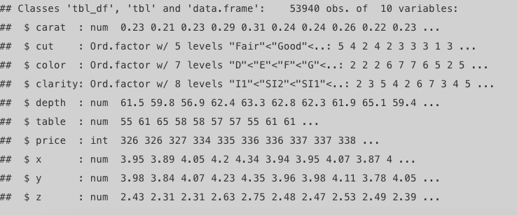

## Diamond App Overview

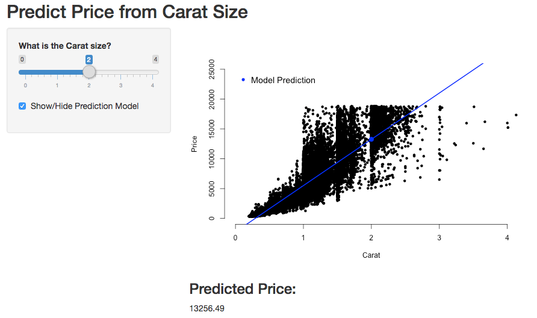

## Code Explained

- Example of code in server.R is shown below.
- Code below shows a regression analysis of the diamond dataset
- Also predicted price based on the carat size selected on the slider bar

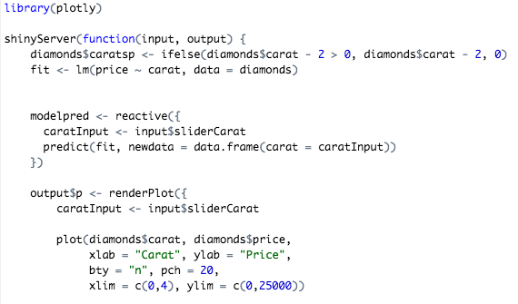

## References

GitHub Repository URL: https://github.com/wpadilla9/developing-data-products/

Application URL: https://wpadilla92.shinyapps.io/predict_app/